# Greenhouse gases development in the Netherlands

December 9, 2016

## Introduction

The Dutch Central Bureau of Statistics has an overview of the development of greenhouse gases within the country.

To get insight into this data a Shiny app has been created where the user can view the development for different emission sources.

This presentation will present some of the more remarkable findings.

All code can be found in my Github repo at  
https://github.com/Tothalvadi/DataProductsWeek4

## Change in emissions between 1990 and 2015 expressed in percentage

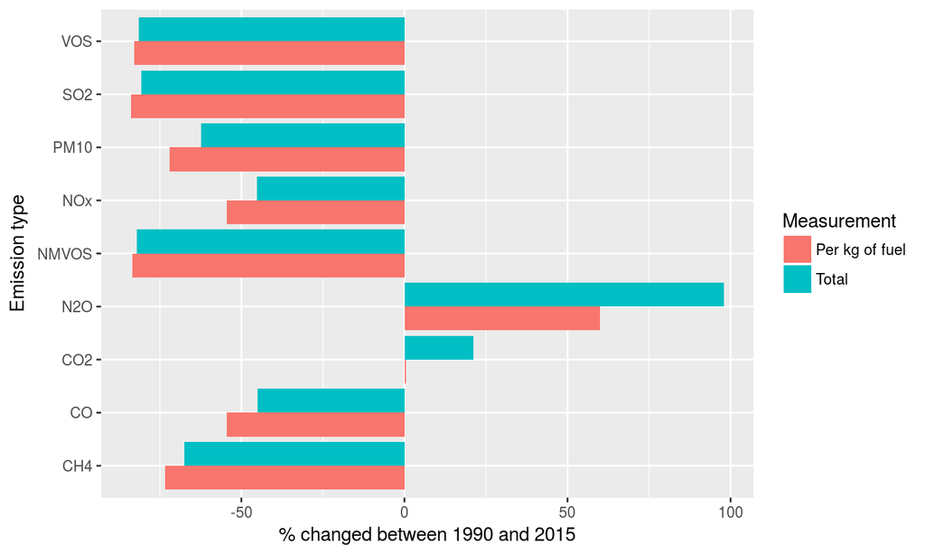

## Specifics?

Of course a total overview doesn't tell the whole story. It would be nice if you could get a more detailed overview per different source.

And now you can! Just jump to the Shiny app and analyse to your heart's content! :)

Go to http://chartable.io/DataProducts/ and take a look!

Thanks for reading my presentation!

PS (It's my own server and not very fast, so give it some time to render :)